# rodent reproductive phenology (male)

Pat Dumandan

12/23/2020

### Reproductive males dataset

```r
all_sp=rbind(PB_props, PE_props, PP_props, PF_props, PM_props, RM_props)%>%
  arrange(repro)
head(all_sp)
```

```
##    X month Month year count       trt repro proportion species
## 1 10     1   Jan 2008    15 exclosure     1 0.06666667      PB
## 2 14     1   Jan 2012     2 exclosure     1 0.50000000      PB
## 3 27     2   Feb 2008    13 exclosure     1 0.07692308      PB
## 4 29     2   Feb 2010     1 exclosure     1 1.00000000      PB
## 5 31     2   Feb 2013     6 exclosure     1 0.16666667      PB
## 6 34     2   Feb 2016     2 exclosure     1 0.50000000      PB
```

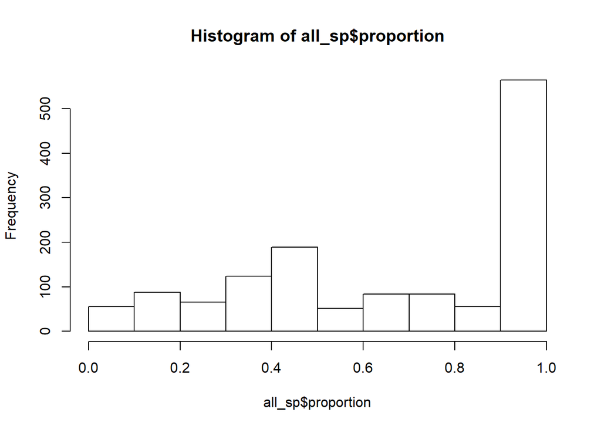

```r
hist(all_sp$proportion)
```

### Hierarchical beta-binomial model

#### A. Data Manipulation

```r
#all_sp$treatment<-ifelse(all_sp$trt=="control", 0, 1)
#all_sp$years=(all_sp$year-mean(all_sp$year))/(2*sd(all_sp$year)) #standardize year
#all_sp[is.na(all_sp)] <- 0 #set non-detects to 0
#all_sp$spcode=as.integer(all_sp$species)

#dat_list=list(
# N=length(all_sp$month),
#  y=all_sp$repro,
#  n=all_sp$count,
#  year=all_sp$years,
#  treatment=all_sp$trt,
#  species=all_sp$spcode,
#  month=all_sp$month,
#  Nmon=length(unique(all_sp$month)),
#  Nsp=length(unique(all_sp$species)))
```

#### B. Model Infrastructure

```r
data{
  int<lower=0> N; // no.of obs
  int <lower=0> y[N];       // reproductive indivs
  int <lower=0>  n[N];       // total males
  vector [N] year;// year
  vector[N] treatment;// treatment
  int month[N]; //ID of each month
  int Nmon; //no.of months
  int species[N]; //species ID
  int Nsp; //no.of species
 }

 parameters {
  real alpha;// intercept
  real year_eff; //slope year
  real trt_eff; //slope treatment effect
  real<lower=0> sigma_mon[Nmon];//error for random intercept (month)
  real <lower=0> mon_non;//non-centered error term for species
  real<lower=0> sigma_sp[Nsp];//error for random intercept (species)
  real <lower=0> sp_non;//non-centered error term for month
  real <lower=0> phi;
  real <lower=0, upper=1> pred_repro[N] ;//proportion of reproductive event
              }

  transformed parameters{
  vector <lower=0, upper=1> [N] repro_mu; //mean estimated proportion of reproductive event
  vector <lower=0> [N] A;
  vector <lower=0> [N] B;
  vector [Nmon] alpha_mon; //random intercept per species
   vector [Nsp] alpha_sp; //random intercept per species
  //vector [Nmon] yr_mon; //random slope per month for year effect
  //vector [Nmon] trt_mon;//random slope per month for treatment effect


  for (j in 1:Nmon) {

  alpha_mon[j]= mon_non*sigma_mon[j];
  }

   for (k in 1:Nsp) {

  alpha_sp[k]= sp_non*sigma_sp[k];
  }

  //model:

  for (i in 1:N){

  repro_mu[i]= inv_logit(alpha+alpha_mon[month[i]]+alpha_sp[species[i]]+ year_eff*year[i]+trt_eff*treatment[i]);
  }

  A = repro_mu * phi;
  B = (1 - repro_mu)* phi;

  }
 model {
  //priors
  year_eff~ normal (0,1);
  trt_eff~ normal (0,1);
  mon_non~ normal(0,1);
  sigma_mon~ normal(0,1);
  phi ~normal(0,1);
  sp_non~ normal(0,1);
  sigma_sp~ normal(0,1);

  //model likelihood:

  pred_repro ~ beta(A, B); // survival estimate, beta dist.
  y~binomial(n, pred_repro); //no.of survivors drawn from binomial dist; based on sample size and reported survival estimate

 }

  generated quantities {

  real pred_y [N];//predictions on proportions
  real log_lik [N];// for looic calculations

    pred_y = beta_rng(A, B);

    for (x in 1:N){
    log_lik[x]= beta_lpdf(pred_repro[x]| A[x], B[x]);}

  }
```

#### C. Model Output

```r
mod1=readRDS("all_sp_betabinom_mod.RDS")
print(mod1, pars=c("alpha","alpha_mon", "alpha_sp","trt_eff", "year_eff"))
```

```
## Inference for Stan model: 347c7f6a31cccc8e843d99d84b2319dd.
## 4 chains, each with iter=3000; warmup=1500; thin=1;
## post-warmup draws per chain=1500, total post-warmup draws=6000.
##
##                mean se_mean   sd  2.5%   25%   50%   75% 97.5% n_eff Rhat
## alpha         -3.08    0.01 0.32 -3.85 -3.25 -3.04 -2.86 -2.59  1464    1
## alpha_mon[1]   0.44    0.01 0.24  0.05  0.28  0.42  0.58  0.99  1471    1
## alpha_mon[2]   1.30    0.01 0.23  0.92  1.15  1.28  1.44  1.80  1868    1
## alpha_mon[3]   2.03    0.00 0.22  1.67  1.88  2.01  2.16  2.52  1874    1
## alpha_mon[4]   2.52    0.01 0.22  2.14  2.37  2.50  2.65  3.02  1792    1
## alpha_mon[5]   2.32    0.01 0.22  1.96  2.17  2.30  2.46  2.83  1704    1
## alpha_mon[6]   1.81    0.01 0.22  1.43  1.66  1.79  1.94  2.31  1860    1
## alpha_mon[7]   1.42    0.01 0.22  1.04  1.27  1.39  1.54  1.91  1781    1
## alpha_mon[8]   1.30    0.01 0.23  0.89  1.14  1.28  1.44  1.81  1739    1
## alpha_mon[9]   1.06    0.01 0.23  0.66  0.91  1.04  1.20  1.60  1813    1
## alpha_mon[10]  0.73    0.01 0.23  0.34  0.57  0.72  0.87  1.24  1753    1
## alpha_mon[11]  0.19    0.00 0.17  0.01  0.06  0.14  0.27  0.62  2533    1
## alpha_mon[12]  0.22    0.00 0.18  0.01  0.08  0.18  0.32  0.67  2260    1
## alpha_sp[1]    1.20    0.01 0.26  0.82  1.03  1.16  1.33  1.87  1790    1
## alpha_sp[2]    0.22    0.00 0.23  0.01  0.06  0.15  0.31  0.85  2758    1
## alpha_sp[3]    2.04    0.01 0.27  1.63  1.86  2.00  2.17  2.70  2014    1
## alpha_sp[4]    0.99    0.01 0.29  0.55  0.80  0.96  1.14  1.68  2005    1
## alpha_sp[5]    1.76    0.01 0.27  1.38  1.59  1.72  1.89  2.44  1862    1
## alpha_sp[6]    1.19    0.01 0.27  0.80  1.01  1.14  1.32  1.87  2133    1
## trt_eff        0.25    0.00 0.07  0.11  0.20  0.25  0.29  0.38  2444    1
## year_eff      -0.73    0.00 0.09 -0.90 -0.78 -0.72 -0.67 -0.56  1685    1
##
## Samples were drawn using NUTS(diag_e) at Sat Jan 02 12:02:38 2021.
## For each parameter, n_eff is a crude measure of effective sample size,
## and Rhat is the potential scale reduction factor on split chains (at
## convergence, Rhat=1).
```

#### D. Model Interpretation

1. community-wide
- mean community-wide proportion of reproductive males across all years

```r
#plogis(alpha+mean year_eff+mean trt_eff)
(plogis(-3.08+-0.73+0.25))*100
```

```
## [1] 2.765242
```

1.a. community-wide (monthly) * mean community-wide proportion of reproductive males across all years in JAN

```r
#plogis(alpha+alpha[1]+year_eff+mean trt_eff)
plogis(-3.08+0.44+-0.73+0.25)*100
```

```
## [1] 4.228977
```

- mean community-wide proportion of reproductive males across all years in FEB

```r
#plogis(alpha+alpha[2]+year_eff+mean trt_eff)
plogis(-3.08+1.3+-0.73+0.25)*100
```

```
## [1] 9.449037
```

- mean community-wide proportion of reproductive males across all years in MAR

```r
#plogis(alpha+alpha[3]+year_eff+mean trt_eff)
plogis(-3.08+2.03+-0.73+0.25)*100
```

```
## [1] 17.79937
```

- mean community-wide proportion of reproductive males across all years in APR

```r
#plogis(alpha+alpha[4]+year_eff+mean trt_eff)
plogis(-3.08+2.52+-0.73+0.25)*100
```

```
## [1] 26.115
```

- mean community-wide proportion of reproductive males across all years in MAY

```r
#plogis(alpha+alpha[5]+year_eff+mean trt_eff)
plogis(-3.08+2.32+-0.73+0.25)*100
```

```
## [1] 22.4436
```

- mean community-wide proportion of reproductive males across all years in JUN

```r
#plogis(alpha+alpha[6]+year_eff+mean trt_eff)
plogis(-3.08+1.81+-0.73+0.25)*100
```

```
## [1] 14.80472
```

- mean community-wide proportion of reproductive males across all years in JUL

```r
#plogis(alpha+alpha[7]+year_eff+mean trt_eff)
plogis(-3.08+1.42+-0.73+0.25)*100
```

```
## [1] 10.52694
```

- mean community-wide proportion of reproductive males across all years in AUG

```r
#plogis(alpha+alpha[8]+year_eff+mean trt_eff)
plogis(-3.08+1.3+-0.73+0.25)*100
```

```
## [1] 9.449037
```

- mean community-wide proportion of reproductive males across all years in SEPT

```r
#plogis(alpha+alpha[9]+year_eff+mean trt_eff)
plogis(-3.08+1.06+-0.73+0.25)*100
```

```
## [1] 7.585818
```

- mean community-wide proportion of reproductive males across all years in OCT

```r
#plogis(alpha+alpha[10]+year_eff+mean trt_eff)
plogis(-3.08+0.73+-0.73+0.25)*100
```

```
## [1] 5.57244
```

- mean community-wide proportion of reproductive males across all years in NOV

```r
#plogis(alpha+alpha[11]+year_eff+mean trt_eff)
plogis(-3.08+0.19+-0.73+0.25)*100
```

```
## [1] 3.324631
```

- mean community-wide proportion of reproductive males across all years in DEC

```r
#plogis(alpha+alpha[12]+year_eff+mean trt_eff)
plogis(-3.08+0.22+-0.73+0.25)*100
```

```
## [1] 3.422416
```

2. species-specific
- PB mean proportion across all years

```r
#plogis(alpha+alpha[1]+year_eff+mean trt_eff)
plogis(-3.08+1.20+-0.73+0.25)*100
```

```
## [1] 8.627419
```

- PE mean proportion across all years

```r
#plogis(alpha+alpha[2]+year_eff+mean trt_eff)
plogis(-3.08+0.22+-0.73+0.25)*100
```

```
## [1] 3.422416
```

```r
#plogis(alpha+alpha[3]+year_eff+mean trt_eff)
plogis(-3.08+2.04+-0.73+0.25)*100
```

```
## [1] 17.94615
```

```r
#plogis(alpha+alpha[4]+year_eff+mean trt_eff)
plogis(-3.08+0.99+-0.73+0.25)*100
```

```
## [1] 7.10943
```

```r
#plogis(alpha+alpha[5]+year_eff+mean trt_eff)
plogis(-3.08+1.76+-0.73+0.25)*100
```

```
## [1] 14.18511
```

- RM mean proportion across all years

```r
#plogis(alpha+alpha[6]+year_eff+mean trt_eff)
plogis(-3.08+1.19+-0.73+0.25)*100
```

```
## [1] 8.548914
```

3. Probability of direction (PD) of effect
- year effect

```r
length(which(male_mod$year_eff<0))/length(male_mod$year_eff)
```

```
## [1] 1
```

*There is a >99% probability that year is negatively associated with the number of reproductive male individuals*

- treatment effect

```r
length(which(male_mod$trt_eff>0))/length(male_mod$trt_eff)
```

```
## [1] 0.9998333
```

*There is a >99% probability that higher values of set-up(1=exclosure, 0=control) are positively associated with the number of reproductive male individuals*

#### E. Data Visualization

1. no.of reproductive individuals across all species in all years per month

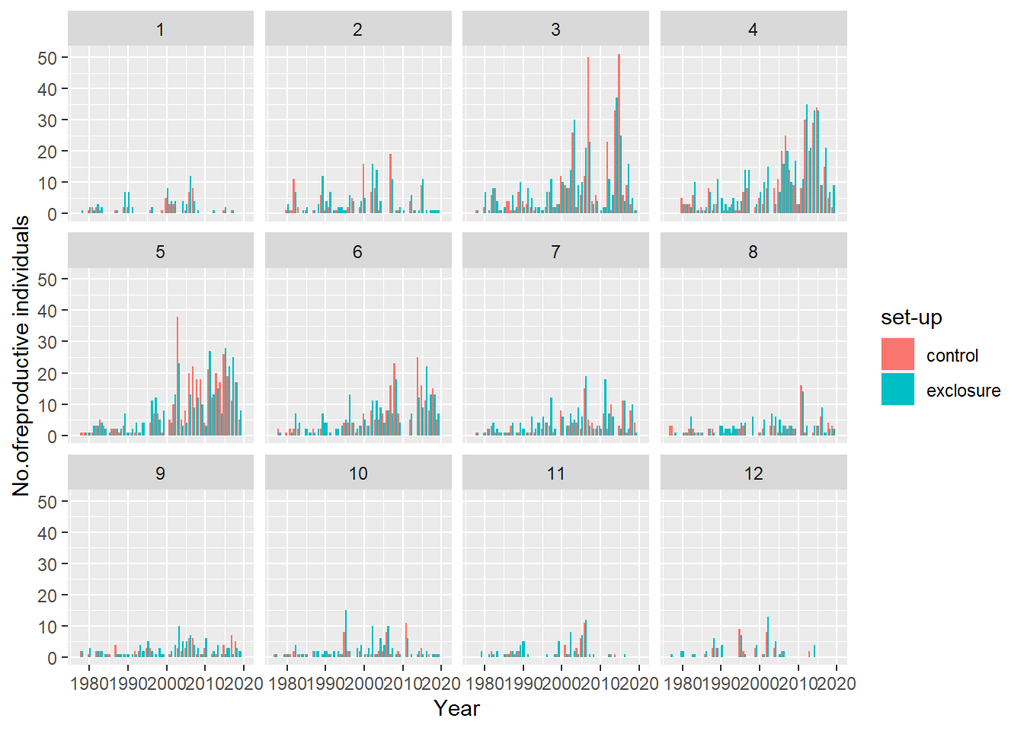

```r
plot_all_month=all_sp%>%
  ggplot(mapping=aes(x=year, y=repro, fill=trt))+
  geom_col(position = position_dodge())+labs(fill="set-up")+
  xlab("Year")+ylab("No.ofreproductive individuals")+
  facet_wrap(~month)
plot_all_month
```

2. no. of reproductive males across all years per species per month

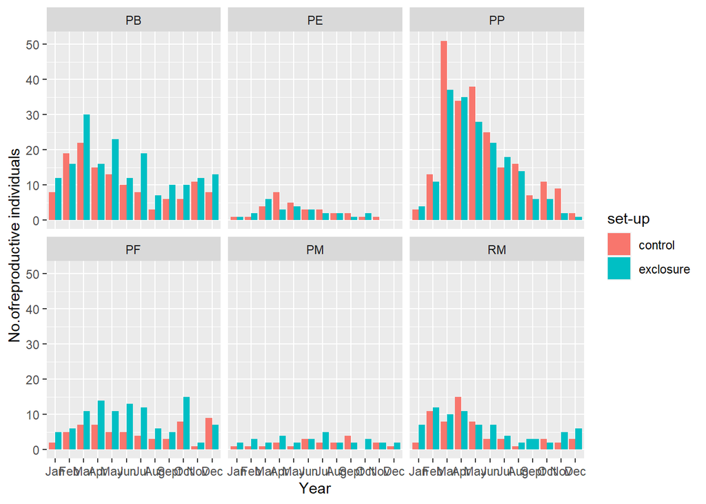

```r
plot_all_raw=all_sp%>%
  ggplot(mapping=aes(x=reorder(Month,month), y=repro, fill=trt))+
  geom_col(position = position_dodge())+labs(fill="set-up")+
  xlab("Year")+ylab("No.ofreproductive individuals")+
  facet_wrap(~species)
plot_all_raw
```

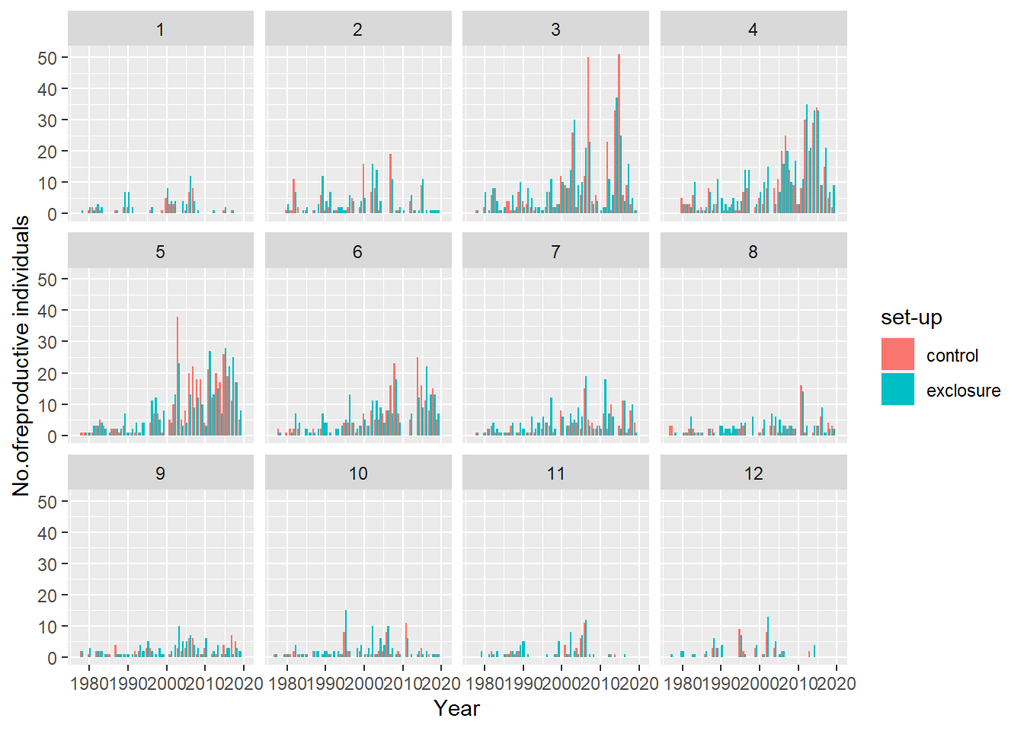

```r
plot_all_year=all_sp%>%
  ggplot(mapping=aes(x=year, y=repro, fill=trt))+
  geom_col(position = position_dodge())+labs(fill="set-up")+
  xlab("Year")+ylab("No.ofreproductive individuals")+
  facet_wrap(~month)
plot_all_year
```

#### *Questions for Morgan*

- do the results sort of make sense (year and treatment effect)/ do you agree with how the results were interpreted?
- I read in the MacLean and Guralnick 2020 paper where they reconstructed breeding phenology of a small mammal that photoperiod was one of the important determinants of their breeding events. would it be worthwhile to add that as a predictor or should we focus on the temporal trends of the proportion of the breeding events and the effect of competition?
- does it make sense to allow the slope (treatment effect) to vary per month as well? (i.e., does it make sense to expect that at a given month, being in the control set-up might be conducive for them because K-rats may be less active?)